# Bio 381 Portfolio

Jules Ford

2023-01-25

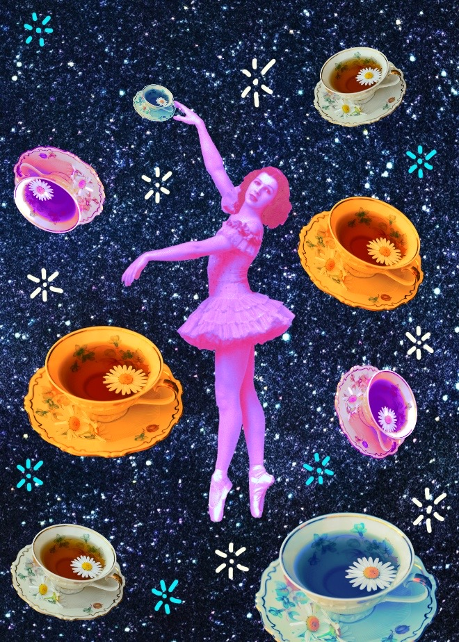

This is my portfolio of homework assignments for Computational Biology!

[Click here to teleport to my GitHub repository! *make sci-fi noises as you click*](https://github.com/Jules-Ford/FordBio381)

Click here to see my Homework 3 file on Regular Expressions.

Click here to see my Homework 4 file on Atomic Vectors.

Click here to see my Homework 5 file on Matrices, Lists, and Data Frames.

Click here to see my Homework 6 file on Functions.

Click here to see my Homework 7 on Simulating and Fitting Data Distributions.

Click here to see my Homework 8 on Creating Fake Data Sets to Explore Hypotheses.

Click here to see my Homework 9 on Organizing Code with Structured Programming.

Click here to see my Homework 10 on For loops and Randomization Tests.

Click here to see my Homework 11 on Batch Processing.

Click here to see my Homework 12 on Advanced ggplotting.

At this point I think I’ve completed all of the homework assignments & problems needed for the portfolio. This was a really fun semester!